# Graph gallery

Installed figures use static projections. To enable 3D rotation and layout selection, render with `options(grip.vignette.interactive = TRUE)` and **ivue** and **rgl** installed.

Explore a structural mesh, a branching power network, a recursive carpet, and a porous volume. Every figure compares **metric-MDS** with **metric-MDS + edge-KK** using the same graph and lengths. The remaining nine examples, including dwt_307, Les Miserables, curved surfaces, and the intrinsic tree, are in the extended gallery.

The layouts use SGD, grip’s default metric-MDS backend. They use uniform stress weights; they do not reproduce the inverse-squared weighting in the Zheng et al. paper. See Metric MDS for that comparison.

## Reading the gallery

**Blue is metric MDS; orange is MDS followed by edge-KK.** Gray, when present, shows the coordinates used to construct the graph. Each visible layout includes all its edges. Switching layouts preserves the camera and scale. Each layout is **Procrustes-aligned** to the generating coordinates (or to metric MDS when no generating coordinates are available). Corresponding vertices are matched by their graph indices; translation and rotation/reflection minimize their summed squared separations. No resizing is used to make the layouts agree. Generating coordinates show where a geometric graph came from, but need not realize its graph shortest-path distances as straight-line separations.

Each graph also supports an interactive 3D view made with ivue. Use the visible layout selector to choose **metric-MDS**, **metric-MDS + edge-KK**, or **both**. Gray generating coordinates remain visible where available. Drag to rotate and scroll to zoom. By default, a static view shows the same metric-MDS coordinates and alignment as the initial interactive view.

Each table reports two errors. **Graph-distance error** measures the fit to all shortest-path distances; **edge-length error** measures the fit to supplied edge lengths. Both are root-mean-square errors divided by the root-mean-square target length, so zero is exact agreement and lower is better. Scores use the returned coordinates without fitting an extra scale. Each stage’s elapsed time is also listed; preparation is excluded, and the refinement time is additional to the MDS time. These are single-workstation timings, not a speed comparison.

## Graphs from applications

### dwt_1005: a structural mesh

A larger structural mesh with 1,005 vertices. Rotate the view to inspect its folds and connections.

**1005 vertices; 3808 edges. Unit edge lengths.**

```r
g <- suitesparse.graph('dwt_1005')
```

[Source and metadata](https://sparse.tamu.edu/HB/dwt_1005).

| Layout | Graph-distance error | Edge-length error | Stage seconds |
| --- | --- | --- | --- |
| Metric MDS | 0.073 | 0.4031 | 14.874 |
| MDS + edge-KK | 0.115 | 0.1904 | 0.029 |

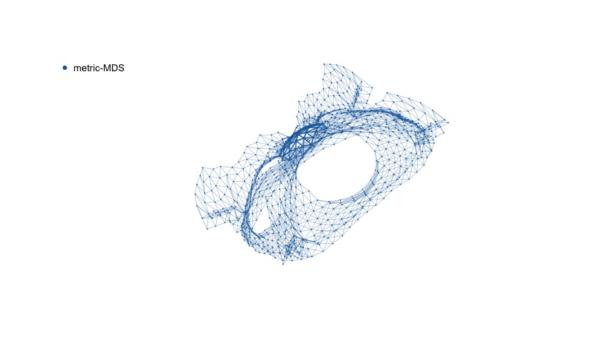

### 1138_bus: a power network

The connectivity of a 1,138-bus power-system matrix, showing branching at a larger scale.

**1138 vertices; 1458 edges. Unit edge lengths.**

```r
g <- suitesparse.graph('1138_bus')
```

[Source and metadata](https://sparse.tamu.edu/HB/1138_bus).

| Layout | Graph-distance error | Edge-length error | Stage seconds |
| --- | --- | --- | --- |
| Metric MDS | 0.1363 | 0.5843 | 19.290 |
| MDS + edge-KK | 0.1510 | 0.1183 | 0.019 |

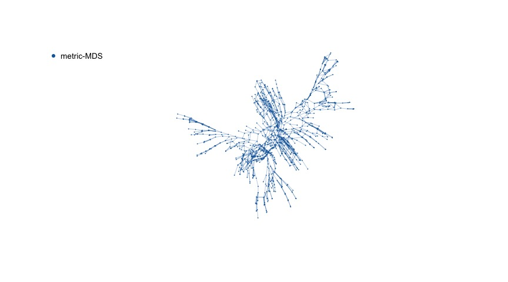

## Generated graphs

### A recursive carpet on a saddle

A recursively perforated grid lifted onto a saddle. Its holes create detours in graph paths.

**64 vertices; 88 edges. Supplied edge lengths.**

| Layout | Graph-distance error | Edge-length error | Stage seconds |
| --- | --- | --- | --- |
| Metric MDS | 0.0886 | 0.3841 | 0.060 |
| MDS + edge-KK | 0.2384 | 0.0080 | 0.003 |

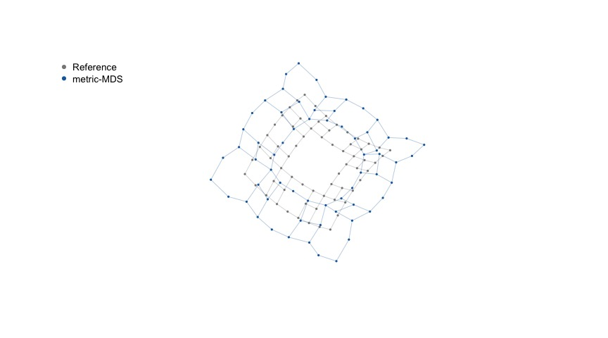

```r
g <- recursive.mask.grid.surface.graph(mask.border(3), level = 2, surface = 'saddle', amplitude = .5, normalize = 'none')
```

### A porous cube

A twisted cubical channel network with interior vertices and several routes through the volume.

**104 vertices; 212 edges. Supplied edge lengths.**

| Layout | Graph-distance error | Edge-length error | Stage seconds |
| --- | --- | --- | --- |
| Metric MDS | 0.1116 | 0.4908 | 0.151 |
| MDS + edge-KK | 0.3466 | 0.0000 | 0.002 |

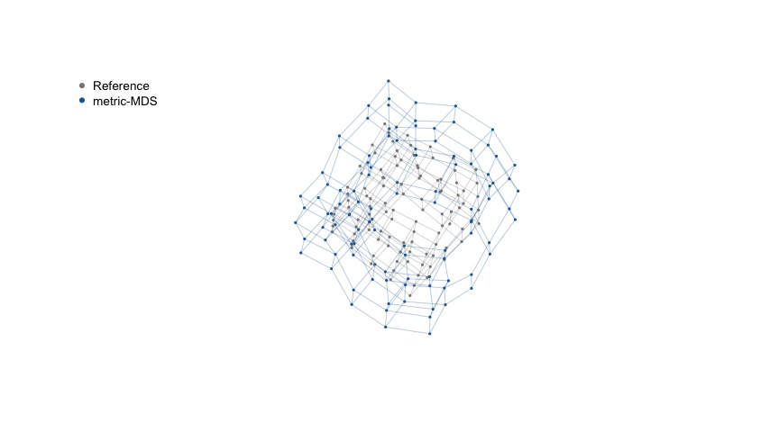

```r
g <- cube.channel.network.surface.graph(side = 5, level = 1, surface = 'twisted', twist = .2, normalize = 'none')
```

## Start with SGD metric MDS

This small example creates a weighted tree and draws it in 3D with SGD. The saved gallery also compares an optional edge-KK stage; it is not a recommended automatic second step.

```r
g <- kary.tree.weighted.graph(k = 2, depth = 5, depth.decay = .85,
                            branch.spread = .2, normalize = 'none')
prepared <- prepare.graph.geodesic.mds(
  edges = g$edges, n = g$n, edge.weights = g$edge_weights)
mds <- suppressWarnings(metric.mds(
  prepared = prepared, dim = 3, backend = 'sgd', init = 'random',
  n.init = 3, max.iter = 80, seed = 2026, diagnostics = FALSE))
```

Use `mds$coords` as the default result. For larger graphs, pass raw graph inputs to `metric.mds(approximation="sparse", backend="sgd", ...)` rather than creating this dense preparation; see sparse MDS.

### Optional edge-length comparison

The following reproduces the gallery’s additional comparison. Retain it only when its independent diagnostics support the intended use.

```r
refined <- edge.kk(
  coords = mds$coords, prepared = prepared, dim = 3,
  stiffness.method = 'uniform', density.mix.schedule = 1,
  scale.mode = 'identity', max.iter = 100,
  return.trace = FALSE, diagnostics = FALSE)
```

MDS tries to fit shortest-path distances between **all pairs of vertices**. Edge-KK adjusts the drawing to fit **directly connected vertices**. Here every edge has equal influence during refinement, and `scale.mode = "identity"` keeps its target length fixed. An improvement in edge lengths can come with a worse fit to distances between more widely separated vertices.

We use three random starts for MDS, retaining the one with the lowest stress, and allow 80 passes per start. Reaching that limit can produce an `iteration_limit` warning; the small example suppresses it, while the saved gallery records it. Refinement allows 100 iterations. These are illustration settings, not settings chosen to make either stage win. All fits use seed 2026.

For the six new datasets, replace the graph-construction line with:

```r
suitesparse.graphs()
```

```
#>                                        id                              name
#> 1                 AG-Monien/netz4504_dual                     netz4504_dual
#> 2                             Bai/bfwa782                           bfwa782
#> 3                              Bai/dw256A                            dw256A
#> 4                              Bai/dw256B                            dw256B
#> 5             Bai/mhda416__LCC_409_of_416           mhda416__LCC_409_of_416
#> 6                               Bai/qh768                             qh768
#> 7                              Bai/rdb450                            rdb450
#> 8                             Bai/rdb800l                           rdb800l
#> 9                               Bai/rw496                             rw496
#> 10                        Boeing/bcsstm34                          bcsstm34
#> 11                        Boeing/msc00726                          msc00726
#> 12                       Bomhof/circuit_2                         circuit_2
#> 13                              CPM/cz628                             cz628
#> 14                        FEMLAB/problem1                          problem1
```

[output cut: 243 more lines]

```r
g <- suitesparse.graph('lesmis')
head(g$vertex_data)
```

```
#>   vertex source_index          label source_partition original_vertex vertex_id
#> 1      1            1         Myriel              row               1       v:1
#> 2      2            2       Napoleon              row               2       v:2
#> 3      3            3 MlleBaptistine              row               3       v:3
#> 4      4            4    MmeMagloire              row               4       v:4
#> 5      5            5   CountessDeLo              row               5       v:5
#> 6      6            6       Geborand              row               6       v:6
#>   source_vertex_id component
#> 1              v:1         1
#> 2              v:2         1
#> 3              v:3         1
#> 4              v:4         1
#> 5              v:5         1
#> 6              v:6         1
```

Each dataset supplies `n`, `edges`, `edge_weights`, `vertex_data`, and `provenance`. For these six examples, vertex indices follow the original matrix rows. The six graphs are connected; no vertices were dropped or connecting edges added. We use unit edge lengths and preserve the original matrix values separately. For example, Les Miserables coappearance counts describe connection strength, so they are not passed to the layout functions as distances.

## More graph constructors

| Need | Public entry points | Output |
| --- | --- | --- |
| Topology alone | `edges.path()`, `edges.mesh()`, `edges.kary.tree()`, the other primitive `edges.*()` generators | Two-column edge matrix; no bundled reference coordinates or lengths. |
| A finite perforated grid | `keep.periodic.holes()`, `keep.asymmetric.notches()`, `keep.slit.channels()`, `keep.staggered.windows()`, then `occupied.mesh.surface.graph()` | A keep matrix followed by a complete weighted graph bundle. |
| A recursive pattern | Square `mask.*()` helpers, cubic `mask.cube.*()` arrays, or triangle/tetrahedron masks, then the matching `recursive.*.surface.graph()` | A mask followed by a recursively generated weighted bundle. |
| A regular reference surface | `mesh.surface.graph()`, `cylinder.surface.graph()`, `sphere.surface.graph()`, `torus.surface.graph()` | Edges, lengths, 3D reference coordinates, and parameters. |
| Irregular surfaces or volumes | The `irregular.*.surface.graph()` and `irregular.*.solid.graph()` families | Deterministic geometric constructions; “irregular” does not imply random sampling. |
| Triangular-lattice or polyhedral topology | The three `triangulated.*.surface.graph()` families | Graph edges and reference coordinates; the public bundles do not expose triangular faces. |
| Randomly sampled rectangle | `sampled.rectangle.surface.graph()` or plural `sampled.rectangle.surface.graphs()` | One graph or a sequence on a shared sampled point set. |
| Intrinsic lengths without an embedding | `kary.tree.weighted.graph()` | Tree edges, lengths, depths, parents, and edge metadata. |

The construction recipes in the extended gallery illustrate additional families. Use complete public bundles; standalone embeddings and specialized edge builders used inside them are internal functions. A name ending in `surface.graph` is not a promise of a triangle mesh: occupied-cube families, for example, connect occupied cells and can include interior vertices.

## Constructing other graph families

Use a constructor when you need controlled topology or generating coordinates. The extended gallery includes executable recipes and 3D views of a folded irregular annulus and a recursive Vicsek pattern. Change one feature at a time when studying its effect. The complete constructor catalog is in Finding your way around grip.

## Repeat the gallery

The small tree example runs when this vignette is built. The gallery uses saved layouts so rebuilding the document does not repeat the larger fits. To draw any graph yourself, use its construction line above followed by the two-step example. Keep `dim = 3` and the same edge lengths in both steps.

The full recipe is installed as `scripts/graph-examples.R`. Instructions for rebuilding the saved layouts and images are in the [reproduction guide](https://github.com/pgajer/grip/blob/main/tools/README.md#graph-examples-gallery). The saved file retains the settings, software version, all MDS starts, warnings, and any unsuccessful fits. This gallery uses dense shortest-path distances; check graph size before increasing the construction sizes substantially.

## Data sources

- Zheng, J. X., Pawar, S. and Goodman, D. F. M. (2018). *Graph Drawing by Stochastic Gradient Descent*. [doi:10.1109/TVCG.2018.2859997](https://doi.org/10.1109/TVCG.2018.2859997).
- Davis, T. A. and Hu, Y. (2011). *The University of Florida Sparse Matrix Collection*. [doi:10.1145/2049662.2049663](https://doi.org/10.1145/2049662.2049663).
- Knuth, D. E. (1993). *The Stanford GraphBase: A Platform for Combinatorial Computing*. Addison-Wesley. Source of the Les Miserables coappearance data.